# Machine_Learning 13_07

MACHINE LEARNING

Supervised ML

Unsupervised ML

Semi supervised ML

Reinforcement learning

```python
# Supervised Machine learning ---- How to identify Supervised ML

if our dataset contains independent(input data) & dependent(output data) variables we can call it as supervised ML problems.

if both independent and dependent data persent in the datasets we can say supervised ML.
```

```python
# Types of supervised ML

1. Regression ----- Labels/target are continues data

2. Classifications ------ Labels are categorical/discrete data


Now, within the supervised ML how to identify that it is Regression problem or classification problems it means that which

model to be created regression or classification.


if label/target/dependent variable contains continuos data we can call it Regression problems
then we have to build regression model.

if label/target/dependent variable are categorical/discrete data then we can say it's classification problem then
we have to build classification model.
```

```python
# Unsupervised ML

in the unsupervised machine learning we have only clustering means grouping. in the unsupervised ML we will not
find a label/target at all. if our dataset don't have a label/target then we can say it's unsupervised ML or clustering problem.
```

```python
# SUPERVISED MACHINE LEARNING ---- REGRESSION

Linear Regression : linear Regression is one of the supervised machine learning model which can be use to solve
the Regression problem, Regression problem are those where you need to predict continues data, you need to estimate
continues data.

predict/estimate continues data like (salary,sales,profit,height,weight) based on the various input. inputs will change
depending on the business.
```

```python
what is Regression Analysis?

Regression in the statistics is the process of predicting a label (or Dependent variable) based on the
feature (independent variable) at hand. Regression is use for time series modeling and finding the casual
effects relationship between the stock prices of the comapny and various factor like customer reputation
and comapany annual performance etc, can be studied using regression.

Regression analysis is an important tool for analyzing and modelling the data.

The use of Regression --- Regression analysis the relationship between two or more features.

lets suppose we want to make an application which predict the chances of admission a students to a foreign university.

The benefits of using Regression as analysis are asvfollows.

it shows the significant relationship between the label (dependent variable) and features (independent variable).

it shows the extent of the impact of multiple independent variable on the dependent variables.

it can also measure these effects even if the variables are on deifferent scale.



These features are enables the data scientist to find the best of independent variables for predictions.


There are two types of Regression

# simple LR
# multiple LR
```

```python
# The problem statements.

This data is about the amounts spent on advertising through different channels like TV, Radio, Newspaper. the goal is to predict
how the expense on each channel affects the sales and is there a way to optimize that sales.
```

```python
# Necessary imports

import pandas as pd
import matplotlib.pyplot as plt
%matplotlib inline
```

```python
data = pd.read_csv('Advertising.csv')  # here features are tv,radio,newspaper which is independent/features variables
                                       # here sales are dependent/label variables.
data.head()
```

|  | Unnamed: 0 | TV | radio | newspaper | sales |
| --- | --- | --- | --- | --- | --- |
| 0 | 1 | 230.1 | 37.8 | 69.2 | 22.1 |
| 1 | 2 | 44.5 | 39.3 | 45.1 | 10.4 |
| 2 | 3 | 17.2 | 45.9 | 69.3 | 9.3 |
| 3 | 4 | 151.5 | 41.3 | 58.5 | 18.5 |
| 4 | 5 | 180.8 | 10.8 | 58.4 | 12.9 |

```python
data.drop(['Unnamed: 0'], axis =1, inplace = True)
```

```python
data.head()
```

|  | TV | radio | newspaper | sales |
| --- | --- | --- | --- | --- |
| 0 | 230.1 | 37.8 | 69.2 | 22.1 |
| 1 | 44.5 | 39.3 | 45.1 | 10.4 |
| 2 | 17.2 | 45.9 | 69.3 | 9.3 |
| 3 | 151.5 | 41.3 | 58.5 | 18.5 |
| 4 | 180.8 | 10.8 | 58.4 | 12.9 |

```python
data.shape
```

```
(200, 4)
```

```python
data.info()            # printing the summary of the dataframe
```

```
<class 'pandas.core.frame.DataFrame'>
RangeIndex: 200 entries, 0 to 199
Data columns (total 4 columns):
 #   Column     Non-Null Count  Dtype
---  ------     --------------  -----
 0   TV         200 non-null    float64
 1   radio      200 non-null    float64
 2   newspaper  200 non-null    float64
 3   sales      200 non-null    float64
dtypes: float64(4)
memory usage: 6.4 KB
```

```python
data.isna().sum()        # finding the count of missing values from different columns
```

```
TV           0
radio        0
newspaper    0
sales        0
dtype: int64
```

```python
# now let's showcase the relationship between the feature and target column.
```

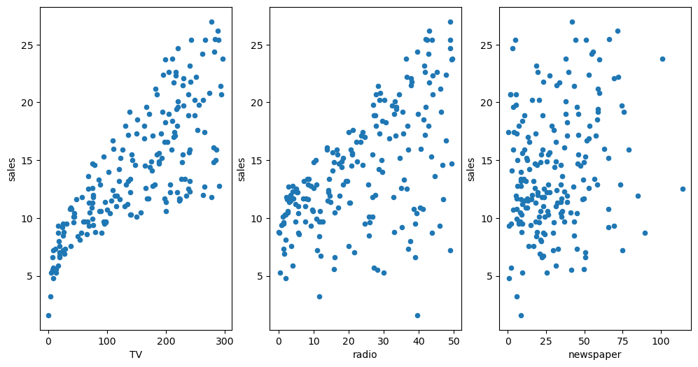

```python
# Visualise the relationship between the features and the response using scatter plot.  for this we need x and y data.
fig, axs = plt.subplots(1, 3)     # (1, 3) means in one row three column to be visualize that's why using subplots
data.plot(kind ='scatter', x='TV', y='sales', ax=axs[0], figsize = (12,6))
data.plot(kind ='scatter', x='radio', y='sales', ax=axs[1])
data.plot(kind ='scatter', x='newspaper', y='sales', ax=axs[2])

fig.savefig('testdata.jpg')
```

```python
# observation by this three figures is that newspaper and sales have not relationship, money investing for advertisment in
# newspaper but sales not increasing its shown
```

```python
SIMPLE LINEAR REGRESSION---simpleLR is a methods for predicting a quantitative response using a single feature('input variable')

y = mx + b

y = y is the response or / target variables

m = slop / coefficient of x

b = intercept

x = input/feature data


To create a model we must learn the values of these coefficient, and once we have the value of coefficients, we can use the
model to predict the sales
```

```python
RESIDUAL --- Residual is the difference(error) between actual value Y and the predicted value Y.

Residual is the error --- The best fit line/regression line/predicted line is obtained by minimizing residual(error).

Residual tell us how good or bad your model is.
```

```python
GREDIENT DESCENT IS A BASICALLY

How it is going to study, how it is going to makeup his mind, when it will make its mind.

that concept is called Gradient descent. the whole concepts is how models work called gradient descent.
```

```python
data.head()
```

|  | TV | radio | newspaper | sales |
| --- | --- | --- | --- | --- |
| 0 | 230.1 | 37.8 | 69.2 | 22.1 |
| 1 | 44.5 | 39.3 | 45.1 | 10.4 |
| 2 | 17.2 | 45.9 | 69.3 | 9.3 |
| 3 | 151.5 | 41.3 | 58.5 | 18.5 |
| 4 | 180.8 | 10.8 | 58.4 | 12.9 |

```python
# Simple Regression only one feature at a time
# x = features, y =label
x = data[['TV']]
y = data.sales

from sklearn.linear_model import LinearRegression                   # scikit learn ---you will find all the model in the sklearn

lm = LinearRegression()

lm.fit(x,y)                    #lm.fit - means training/learning from the data, trying to find the relationship between x and y.
```

```
LinearRegression()
```

```python
#Now its understood x and y (feature and label) what is the relation, what is the pattern.
```

```python
# print intercept and coefficient
print(lm.intercept_)
print(lm.coef_)
```

```
7.032593549127693
[0.04753664]
```

```python
lm.predict([[50]])    # y = mx + c - we already got m and c then, here putting x value to predict, the Y (label) only one value
```

```
array([9.40942557])
```

```python
# if we want to trust the model we need to check the accuracy, if the accuracy is good then only i can use that model for
# future predictions.

# How to findout the model accuracy or model confidence --- we need to understand the metrics.

# Metrics is the model evalution tools

1. R square statistics --- R square stats is basically tells us that how good is our model 20%, 30%, 90% good.

R square will be begin 0 - 1 always we can multiply by x 100 and get in terms of = %.

it represnt that how much of our data is being explained by our model. for example =  Rsquare-stats = 0.75 or 75%
```

```python
Metrics to check model performance (r2_score) --- it will find the model confidence
```

```python
from sklearn.metrics import r2_score
```

```python
# pass all TV records and predict the sales
predicted_sales = lm.predict(x)
```

```python
x.head()
```

|  | TV |
| --- | --- |
| 0 | 230.1 |
| 1 | 44.5 |
| 2 | 17.2 |
| 3 | 151.5 |
| 4 | 180.8 |

```python
predicted_sales
```

```
array([17.97077451,  9.14797405,  7.85022376, 14.23439457, 15.62721814,
        7.44616232,  9.76595037, 12.74649773,  7.44140866, 16.53041431,
       10.17476548, 17.23871025,  8.16396559, 11.66741599, 16.73482186,
       16.32125309, 10.25557777, 20.40940417, 10.32212907, 14.03474068,
       17.41459582, 18.31779199,  7.6600772 , 17.88520856,  9.99412625,
       19.52997632, 13.82557947, 18.44614092, 18.85970969, 10.38868036,
       20.95607553, 12.39948025, 11.653155  , 19.65832525, 11.58185004,
       20.85149492, 19.72012288, 10.58358059,  9.08142275, 17.87094757,
       16.65876324, 15.44657891, 20.98935118, 16.86792445,  8.22576322,
       15.35625929, 11.2966302 , 18.43663359, 17.83291826, 10.21279479,
       16.53041431, 11.80527225, 17.31952254, 15.71278409, 19.52046899,
       16.48763133,  7.37961102, 13.50708398, 17.05331735, 17.04856369,
        9.57580381, 19.45391769, 18.4081116 , 11.91460652, 13.26464711,
       10.31262174,  8.52999772, 13.65444756, 18.31779199, 17.3385372 ,
       16.49713866, 12.25211667,  8.30657551, 13.18383482, 17.17691262,
        7.83596277,  8.33985116, 12.76075872,  7.28929141, 12.54684384,
       10.66439288, 18.43187992, 10.61210257, 10.28409975, 17.18166628,
       16.21667248, 10.65963921, 12.29489965, 11.2300789 , 12.25211667,
       13.41676436,  8.39214147, 17.38132017, 18.95953663, 12.13802873,
       14.79532693, 16.4258337 , 15.82211837, 20.80395828, 13.45954734,
       17.60474238, 21.12245377, 20.3523602 , 15.96472829, 18.3558213 ,
       13.58789626,  8.22100956, 11.32990584,  7.65532354, 19.17345152,
       17.76636696, 18.52219954, 15.38478127, 16.99627338, 10.74995883,
       10.60259525, 13.6496939 , 10.66439288, 13.00794925,  7.95480437,
       13.74952084,  7.92628239, 17.68080101, 12.88435399, 17.94225253,
       11.17778859,  7.40337934, 10.84503211, 17.50491544,  9.86577732,
        7.0658692 , 19.63931059,  7.43190133, 17.48114712,  8.78669558,
        9.32861328,  8.24953154, 20.04337204,  9.07666909, 15.82211837,
       10.52178296, 16.2404408 , 17.51442276, 12.00492614, 11.60561836,
       13.7019842 , 18.44614092, 18.5935045 ,  8.83898589,  9.15748138,
       20.37612852, 12.78452704, 16.4258337 , 15.17562006, 15.95997462,
        7.22749377, 11.49628409, 14.15358229,  7.58877224, 13.29316909,
       15.23266402, 11.10648363, 15.98849661, 14.80483426, 12.60388781,
       18.17993573,  7.88349941, 16.86317079, 17.2719859 , 20.54726042,
        9.40942557, 14.8523709 ,  7.9643117 , 15.0377638 , 17.60474238,
       20.19548929, 18.84069503, 15.12332975, 20.18598196, 14.9046612 ,
       14.47683144, 17.41934948,  9.70415274, 20.70413134, 19.09739289,
       16.77760484, 13.66395489, 16.11684554, 20.62807271,  7.92152873,
        8.91029085, 10.6216099 ,  7.85022376, 14.96170517, 14.14882862,
        8.84849321, 11.51054508, 15.44657891, 20.51398478, 18.06584779])
```

```python
# Lets compare original sales numbers with our model predicted sales
r2_score(y_true=y, y_pred=predicted_sales)
```

```
0.611875050850071
```

```python
so 0.611 X 100 = 61.1%   that is r2-stats --- we generaly use for simple regression model to find the model accuracy
```

```python
# MULTIPLE LINEAR REGRESSION
```

```python
If we use multiple features for the prediction we need to use Adjusted r2_stats to find the confidence or accuracy of the model
```

```python
# Multiple linear regression --- till now we have created the model based on only one feature, Now we will include multiple
# features and create a model to see the relationship between those features and the label column. this is called
# multiple linear regression
```

```python
x = data[['TV', 'radio', 'newspaper']]
y = data.sales

lm = LinearRegression()

lm.fit(x,y)

# print intercept and coefficient
print('intercept : -> ', lm.intercept_)
print('TV  : -> ', lm.coef_[0])
print('radio  : -> ', lm.coef_[1])      # coefficient means its shows the increasement of sales how much its increasing
print('newspaper  : -> ', lm.coef_[2])  # and here newspaper showing -ve coef means the money spent for newspaper advertisment
                                        # is not contributing in a +ve way to the sales
```

```
intercept : ->  2.9388893694594067
TV  : ->  0.04576464545539761
radio  : ->  0.18853001691820462
newspaper  : ->  -0.0010374930424762972
```

```python
Project_1 with Linear Regression

Problem statement

We need to predict the chance of admission based on the students various score

Features or independent variables

GRE Score
TOEFL Score
University Rating
SOP
LOR
CGPA
Research

Label/Target

Chance of Admit


Always refer scikit-learn official documentation if you are not sure about syntax or parameter
```

```python
# Lets's start with importing necessary libraries
import pandas as pd
import numpy as np
from sklearn.preprocessing import StandardScaler

from sklearn.linear_model import LinearRegression

from sklearn.model_selection import train_test_split

import matplotlib.pyplot as plt

import seaborn as sns

import pickle

import warnings
warnings.filterwarnings('ignore')
```

```python
#Read csv file and convert into dataframe
data = pd.read_csv('Admission_Prediction.csv')

data.head()
```

|  | Serial No. | GRE Score | TOEFL Score | University Rating | SOP | LOR | CGPA | Research | Chance of Admit |
| --- | --- | --- | --- | --- | --- | --- | --- | --- | --- |
| 0 | 1 | 337.0 | 118.0 | 4.0 | 4.5 | 4.5 | 9.65 | 1 | 0.92 |
| 1 | 2 | 324.0 | 107.0 | 4.0 | 4.0 | 4.5 | 8.87 | 1 | 0.76 |
| 2 | 3 | NaN | 104.0 | 3.0 | 3.0 | 3.5 | 8.00 | 1 | 0.72 |
| 3 | 4 | 322.0 | 110.0 | 3.0 | 3.5 | 2.5 | 8.67 | 1 | 0.80 |
| 4 | 5 | 314.0 | 103.0 | 2.0 | 2.0 | 3.0 | 8.21 | 0 | 0.65 |

```python
data.shape
```

```
(500, 9)
```

```python
DATA PREPROCESSING STEPS

1. Data cleaning

2. EDA(Analysis)

3. Finding and Treating Outliers(if any)

4. Features selection of model building

5. Data standardization

6. train test split
```

```python
# Data preprocessing
# EDA (Analysis)
# Data cleaning
# Finding and treating outliers(if any)
# features selection for model building (Droping unwanted column)

data = data.drop(columns = ['Serial No.'])

data.head()
```

|  | GRE Score | TOEFL Score | University Rating | SOP | LOR | CGPA | Research | Chance of Admit |
| --- | --- | --- | --- | --- | --- | --- | --- | --- |
| 0 | 337.0 | 118.0 | 4.0 | 4.5 | 4.5 | 9.65 | 1 | 0.92 |
| 1 | 324.0 | 107.0 | 4.0 | 4.0 | 4.5 | 8.87 | 1 | 0.76 |
| 2 | NaN | 104.0 | 3.0 | 3.0 | 3.5 | 8.00 | 1 | 0.72 |
| 3 | 322.0 | 110.0 | 3.0 | 3.5 | 2.5 | 8.67 | 1 | 0.80 |
| 4 | 314.0 | 103.0 | 2.0 | 2.0 | 3.0 | 8.21 | 0 | 0.65 |

```python
# understand data at high level. check the statistics of data set.

data.describe()
```

|  | GRE Score | TOEFL Score | University Rating | SOP | LOR | CGPA | Research | Chance of Admit |
| --- | --- | --- | --- | --- | --- | --- | --- | --- |
| count | 485.000000 | 490.000000 | 485.000000 | 500.000000 | 500.00000 | 500.000000 | 500.000000 | 500.00000 |
| mean | 316.558763 | 107.187755 | 3.121649 | 3.374000 | 3.48400 | 8.576440 | 0.560000 | 0.72174 |
| std | 11.274704 | 6.112899 | 1.146160 | 0.991004 | 0.92545 | 0.604813 | 0.496884 | 0.14114 |
| min | 290.000000 | 92.000000 | 1.000000 | 1.000000 | 1.00000 | 6.800000 | 0.000000 | 0.34000 |
| 25% | 308.000000 | 103.000000 | 2.000000 | 2.500000 | 3.00000 | 8.127500 | 0.000000 | 0.63000 |
| 50% | 317.000000 | 107.000000 | 3.000000 | 3.500000 | 3.50000 | 8.560000 | 1.000000 | 0.72000 |
| 75% | 325.000000 | 112.000000 | 4.000000 | 4.000000 | 4.00000 | 9.040000 | 1.000000 | 0.82000 |
| max | 340.000000 | 120.000000 | 5.000000 | 5.000000 | 5.00000 | 9.920000 | 1.000000 | 0.97000 |

```python
data.info()                 # printing the summary of the dataframe
```

```
<class 'pandas.core.frame.DataFrame'>
RangeIndex: 500 entries, 0 to 499
Data columns (total 8 columns):
 #   Column             Non-Null Count  Dtype
---  ------             --------------  -----
 0   GRE Score          485 non-null    float64
 1   TOEFL Score        490 non-null    float64
 2   University Rating  485 non-null    float64
 3   SOP                500 non-null    float64
 4   LOR                500 non-null    float64
 5   CGPA               500 non-null    float64
 6   Research           500 non-null    int64
 7   Chance of Admit    500 non-null    float64
dtypes: float64(7), int64(1)
memory usage: 31.4 KB
```

```python
data.isna().sum()          # finding the count of missing value from different column
```

```
GRE Score            15
TOEFL Score          10
University Rating    15
SOP                   0
LOR                   0
CGPA                  0
Research              0
Chance of Admit       0
dtype: int64
```

```python
# Fill the Null value using mode if categorical column ---- use mean/average for continues data columns to fill null
data['University Rating'] = data['University Rating'].fillna(data['University Rating'].mode()[0])
data['TOEFL Score'] = data['TOEFL Score'].fillna(data['TOEFL Score'].mean())
data['GRE Score'] = data['GRE Score'].fillna(data['GRE Score'].mean())
```

```python
# verify if nan are filled
data.isna().sum()
```

```
GRE Score            0
TOEFL Score          0
University Rating    0
SOP                  0
LOR                  0
CGPA                 0
Research             0
Chance of Admit      0
dtype: int64
```

```python
data.describe()
```

|  | GRE Score | TOEFL Score | University Rating | SOP | LOR | CGPA | Research | Chance of Admit |
| --- | --- | --- | --- | --- | --- | --- | --- | --- |
| count | 500.000000 | 500.000000 | 500.000000 | 500.000000 | 500.00000 | 500.000000 | 500.000000 | 500.00000 |
| mean | 316.558763 | 107.187755 | 3.118000 | 3.374000 | 3.48400 | 8.576440 | 0.560000 | 0.72174 |
| std | 11.103952 | 6.051338 | 1.128993 | 0.991004 | 0.92545 | 0.604813 | 0.496884 | 0.14114 |
| min | 290.000000 | 92.000000 | 1.000000 | 1.000000 | 1.00000 | 6.800000 | 0.000000 | 0.34000 |
| 25% | 309.000000 | 103.000000 | 2.000000 | 2.500000 | 3.00000 | 8.127500 | 0.000000 | 0.63000 |
| 50% | 316.558763 | 107.000000 | 3.000000 | 3.500000 | 3.50000 | 8.560000 | 1.000000 | 0.72000 |
| 75% | 324.000000 | 112.000000 | 4.000000 | 4.000000 | 4.00000 | 9.040000 | 1.000000 | 0.82000 |
| max | 340.000000 | 120.000000 | 5.000000 | 5.000000 | 5.00000 | 9.920000 | 1.000000 | 0.97000 |

```python
Now the data looks good and there are no missing values.
```

# Let's Visualize the data and analyze the relationship between independent and dependent variables

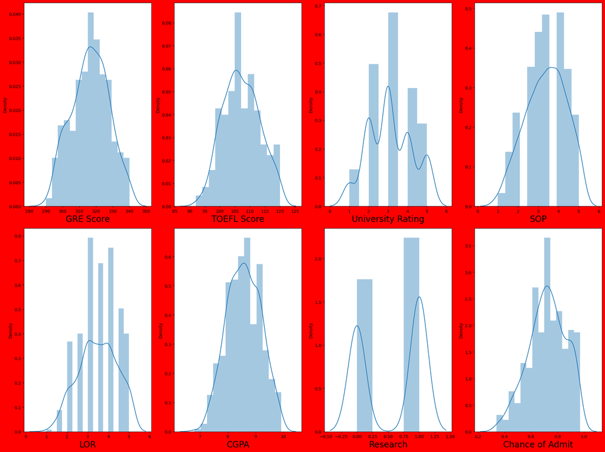

```python
# Let's see how data is distributed for every column

plt.figure(figsize = (20,15), facecolor = 'red')  # figsize means lenth and width of the plot
plotnumber = 1

for column in data:
    if plotnumber<=8:                            # 8 means total columns in the data
        ax = plt.subplot(2,4,plotnumber)         # 2,4 means two rows with four column
        sns.distplot(data[column])               # Distribution plot
        plt.xlabel(column, fontsize = 20)

    plotnumber+=1
plt.tight_layout()                              # tight_layout() means it is similar to plt.show()
```

```python
The data distribution looks decent enough and there doesn't seem to be any skewness. showing that bell shape curve its good data

Let's observed relationship between independent variable and dependent variable
```

```python
# Divide dataset into features and label
y = data['Chance of Admit']
x = data.drop(columns = ['Chance of Admit'])
```

```python
y
```

```
0      0.92
1      0.76
2      0.72
3      0.80
4      0.65
       ...
495    0.87
496    0.96
497    0.93
498    0.73
499    0.84
Name: Chance of Admit, Length: 500, dtype: float64
```

```python
x
```

|  | GRE Score | TOEFL Score | University Rating | SOP | LOR | CGPA | Research |
| --- | --- | --- | --- | --- | --- | --- | --- |
| 0 | 337.000000 | 118.0 | 4.0 | 4.5 | 4.5 | 9.65 | 1 |
| 1 | 324.000000 | 107.0 | 4.0 | 4.0 | 4.5 | 8.87 | 1 |
| 2 | 316.558763 | 104.0 | 3.0 | 3.0 | 3.5 | 8.00 | 1 |
| 3 | 322.000000 | 110.0 | 3.0 | 3.5 | 2.5 | 8.67 | 1 |
| 4 | 314.000000 | 103.0 | 2.0 | 2.0 | 3.0 | 8.21 | 0 |
| ... | ... | ... | ... | ... | ... | ... | ... |
| 495 | 332.000000 | 108.0 | 5.0 | 4.5 | 4.0 | 9.02 | 1 |
| 496 | 337.000000 | 117.0 | 5.0 | 5.0 | 5.0 | 9.87 | 1 |
| 497 | 330.000000 | 120.0 | 5.0 | 4.5 | 5.0 | 9.56 | 1 |
| 498 | 312.000000 | 103.0 | 4.0 | 4.0 | 5.0 | 8.43 | 0 |
| 499 | 327.000000 | 113.0 | 4.0 | 4.5 | 4.5 | 9.04 | 0 |

500 rows × 7 columns

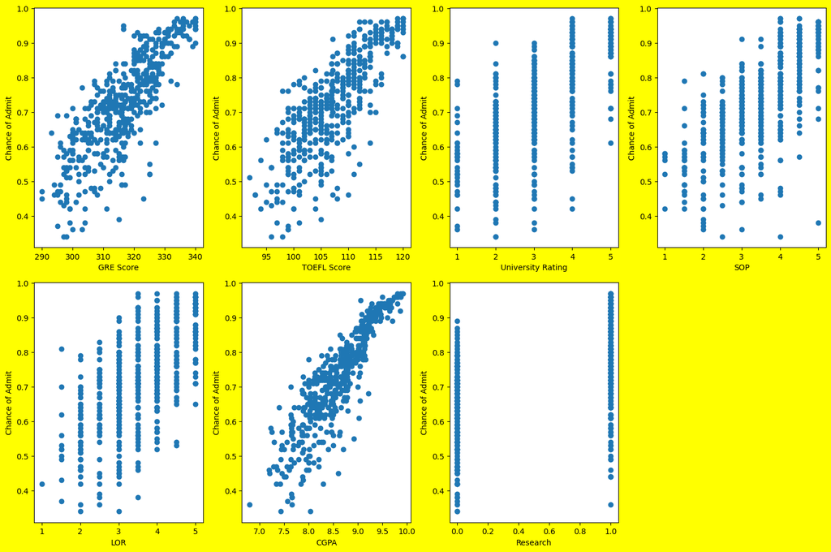

```python
# Visualising relationship

plt.figure(figsize = (15,10), facecolor = 'yellow')  # figsize means lenth and width of the plot
plotnumber = 1

for column in x:
    if plotnumber<=8:                            # 8 means total columns in the data
        ax = plt.subplot(2,4,plotnumber)         # 2,4 means two rows with four column
        plt.scatter(x[column],y)                 # scatter plot
        plt.xlabel(column, fontsize = 10)
        plt.ylabel('Chance of Admit',fontsize = 10)

    plotnumber+=1
plt.tight_layout()                               # tight_layout() means it is similar to plt.show()
```

```python
when you looking for relationship doesnt matter it is categorical data or continues data or columns.

The relationship between the dependent and independent variables look fairly linear.

in this relationships finding that there is good relationship between features and label so that we are not going to
skip any features. if any we can skip that features.

and there is no any outliers persent here in the data if any outliers persent then we can go for boxplot to find out outliers.

we want to quality data to build a model.

quality data means if the data distribution is normal (no skewness right or left) we can say it's an quality data.
```

```python
# data scalling --- formula -- z = (x-mean)/std

scaler = StandardScaler()            # scalling the data means for give importance for every features data

x_scaled = scaler.fit_transform(x)   # .fit means learn from data and transform means apply the formula on features(x)
```

```python
x_scaled
```

```
array([[ 1.84274116e+00,  1.78854223e+00,  7.82009548e-01, ...,
         1.09894429e+00,  1.77680627e+00,  8.86405260e-01],
       [ 6.70814288e-01, -3.10581135e-02,  7.82009548e-01, ...,
         1.09894429e+00,  4.85859428e-01,  8.86405260e-01],
       [ 5.12433309e-15, -5.27312752e-01, -1.04622593e-01, ...,
         1.73062093e-02, -9.54042814e-01,  8.86405260e-01],
       ...,
       [ 1.21170361e+00,  2.11937866e+00,  1.66864169e+00, ...,
         1.63976333e+00,  1.62785086e+00,  8.86405260e-01],
       [-4.10964364e-01, -6.92730965e-01,  7.82009548e-01, ...,
         1.63976333e+00, -2.42366993e-01, -1.12815215e+00],
       [ 9.41258951e-01,  9.61451165e-01,  7.82009548e-01, ...,
         1.09894429e+00,  7.67219636e-01, -1.12815215e+00]])
```

```python
Example for StandardScaler
```

```python
help(LinearRegression)
```

# train_test_split

```python
Build/train the model ---> test the model ---> Accuracy


Divide the data into two parts first for training purpose and testing purpose

we usually divide the for tarining pupose 70 to 80 % and for testing purpose 20% 0r (75% and 25%).
```

```python
# split data into train and test. Model will be built on training data and tested on test data.
x_train,x_test,y_train,y_test = train_test_split(x_scaled,y,test_size = 0.25, random_state = 348)

y_train.head()
```

```
459    0.89
174    0.87
399    0.95
374    0.39
355    0.73
Name: Chance of Admit, dtype: float64
```

# untill this part all above steps are pre processing steps.

```python
# Now Model instantiating and training
```

```python
regression = LinearRegression()

regression.fit(x_train, y_train)
```

```
LinearRegression()
```

```python
# predict the chance of admission given features --- suppose for one student--- demo purpose only
```

```python
data.tail(2)
```

|  | GRE Score | TOEFL Score | University Rating | SOP | LOR | CGPA | Research | Chance of Admit |
| --- | --- | --- | --- | --- | --- | --- | --- | --- |
| 498 | 312.0 | 103.0 | 4.0 | 4.0 | 5.0 | 8.43 | 0 | 0.73 |
| 499 | 327.0 | 113.0 | 4.0 | 4.5 | 4.5 | 9.04 | 0 | 0.84 |

```python
# since we have already fit the scaler, you can transform the data
print('Chance of Admissiom :', regression.predict(scaler.transform([[327.0,113.0,4.0,4.5,4.5,9.04,0]])))
```

```
Chance of Admissiom : [0.82445851]
```

```python
you can save the model and later you can use it for prediction
```

```python
# saving the model to the local file system             # for saving use pickle.dump and for open use pickle.load
pickle.dump(regression, open('reg_model', 'wb'))       # 'reg_model you can save as any name' -- wb means write, rb for read
```

```python
# prediction using the saved model
loaded_model = pickle.load(open('reg_model', 'rb'))
a = loaded_model.predict(scaler.transform([[314,103,2,2,3,8.21,0]]))

a
```

```
array([0.63715829])
```

```python
# Let's check how well model fits on train data
```

```python
# Adjusted R square score --- how our model understand the train data --- its saying i understood upto 82%
regression.score(x_train,y_train)
```

```
0.82855357382842
```

```python
# Let's check how well model fits on test data ---- its understand 79% of test data
regression.score(x_test,y_test)
```

```
0.7928310580010802
```

```python
lets understand why test score is smaller than train score --->>> because we give 75% of data for train the model and 25%
for test that is the reason test score is smaller than train score. training is more data but test is less data to the model.
```

```python
lets plot and visualize
```

```python
x_test[1]
```

```
array([2.11318582, 0.79603295, 0.78200955, 1.64240413, 1.09894429,
       1.79335687, 0.88640526])
```

```python
y_pred = regression.predict(x_test)

y_pred
```

```
array([0.8207641 , 0.94873455, 0.91113259, 0.61044355, 0.66137595,
       0.60352359, 0.83223756, 0.63090419, 0.78083483, 0.76003632,
       0.61343331, 0.5171975 , 0.84481161, 0.47026296, 0.9080331 ,
       0.62012908, 0.73074873, 0.63424789, 0.82329681, 0.57632803,
       0.80849253, 0.75415425, 0.65115419, 0.53199278, 0.55202691,
       0.49318412, 0.8954953 , 0.77677743, 0.72036651, 0.42326242,
       0.82315696, 0.79339286, 0.62530834, 0.67328918, 0.77417537,
       0.63745613, 0.80739236, 0.78788545, 0.58911428, 0.66156995,
       0.73593055, 0.59762008, 0.86327735, 0.94441147, 0.98184889,
       0.51308745, 0.77626965, 0.92424654, 0.63718128, 0.96940982,
       0.65572611, 0.63867889, 0.81411786, 0.73643354, 0.68692311,
       0.55261258, 0.43652872, 0.64497596, 0.68382796, 0.68701788,
       0.86409285, 0.67198884, 0.78792379, 0.65534022, 0.95792159,
       0.61596565, 0.72449619, 0.53769901, 0.59184804, 0.78917924,
       0.74441132, 0.6447335 , 0.99270469, 0.66219368, 0.6520046 ,
       0.730432  , 0.91824184, 0.57612897, 0.59100337, 0.89619341,
       0.47152632, 0.66190723, 0.79367155, 0.71043084, 0.78233434,
       0.65963522, 0.65572924, 1.00430294, 0.81441399, 0.52548688,
       0.7345198 , 0.82498295, 0.65050054, 0.65698214, 0.58344019,
       0.7634334 , 0.88028481, 0.65808647, 0.50882596, 0.71234269,
       0.78374706, 0.51384499, 0.84626944, 0.84477389, 0.6579394 ,
       0.67800339, 0.55618222, 0.57647227, 0.62594456, 0.57834584,
       0.83798218, 0.84126535, 0.59639206, 0.81614983, 0.63828867,
       0.64712715, 0.78755268, 0.60270901, 0.60259444, 0.72251722,
       0.73038231, 0.8460889 , 0.52655296, 0.80393768, 0.85492098])
```

```python
# Now check actual label vs predicted label (y_test) vs (y_pred)
```

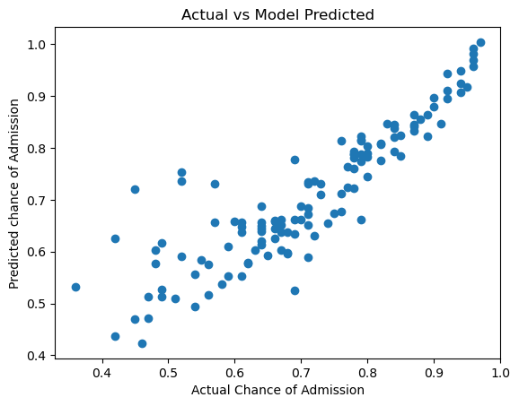

```python
plt.scatter(y_test,y_pred)
plt.xlabel('Actual Chance of Admission')
plt.ylabel('Predicted chance of Admission')
plt.title('Actual vs Model Predicted')
plt.show()
```

```python
Model Evaluation/ To judge the model ---- using metrics it will compare actual and predicted label to findout error using
different kinds of metrics.

1. Mean absolute error(MAE) : Represent average error/overall error (actual label vs predicted label) always.

2. Mean squared error(MSE) : similar to MAE but noise/outliers  is exaggerated and larger errors are 'punished'. it is harder
to interpret than MAE as its not in base unit however, it is generally more popular.

3. Root mean squared error(RMSE) : Most popular metrics, similar to MSE, however, The result is squared rooted to make it
more interpretable as its in base units. it is recommended that RMSE be used as the primary metric to interpret your model.
```

```python
from sklearn.metrics import mean_squared_error, mean_absolute_error
```

```python
# MAE
mean_absolute_error(y_test, y_pred)
```

```
0.04421359936541998
```

```python
#MSE
mean_squared_error(y_test, y_pred)
```

```
0.004309172332351598
```

```python
#RMSE
np.sqrt(mean_squared_error(y_test, y_pred))
```

```
0.06564428636485888
```

# you have succesfully completed building linear regression model

```python
# Now lets check if our model is overfitting our data using regularization
```

```python
Regularization

When we use regression models to train some data. there is a good chance that the model will overfit the given trining
data set. Regularization helps sort this overfitting problem by restricting the degrees of freedom of a given equation.
simply reducing the number of degrees of a polynomial function by reducing their corresponding weights.

in a linear equation, we do not want huge weights/coefficients as a small change in weight can make a large difference
for the dependent variable(y). so regularization constraints the weights of such features to avoid overfitting.

Different types of Regularization in regression --->>>

LASSO(L1 FORM) Least absolute shrinkage and selection operator--->>> Lasso acts as a features selections if features doesn't
make any relation with the label it completely ignore them zero.


RIDGE(L2 FORM) --- ridge regression is same as Lasso but its not completely ignore them (less ignore)

ELASTICNET



why use regularization?

we can not say to model how slowly/fast understand/learn the data its work own speed to learn the data but we can control it.
how slowly? means Learning_Rate. (slow speed more learning).

we need to find the best learning rate, once i get to know what is the best learning rate then that learning rate i can give
into Lasso and Ridge to build a model and that time it learns very nice and give us best result.

so how do i get the learning rate now....

for Lasso --- lassoCV    CV means cross validation
for Ridge --- RidgeCV    CV means cross validation

it will find out the best learning rate that learning rate we will pass to Lasso and Ridge.
```

```python
# split data into train and test. Model will be built on training data and tested on test data.
x_train,x_test,y_train,y_test = train_test_split(x_scaled,y,test_size = 0.25, random_state = 348)
```

```python
from sklearn.linear_model import Ridge,Lasso,RidgeCV,LassoCV
```

```python
Lasso Regularization

LassoCV will return the best alphas after max iteration.

alphas --- it is a learning rate

iteration --- max 10 times
```

```python
lasscv = LassoCV(alphas = None, max_iter = 10)
lasscv.fit(x_train,y_train)
```

```
LassoCV(max_iter=10)
```

```python
# best alpha parameter
alpha = lasscv.alpha_
alpha
```

```
0.0006090008804969982
```

```python
# Now that we have best parameter,lets use Lasso regression and see how well our data has fitted before
lasso_reg = Lasso(alpha)
lasso_reg.fit(x_train, y_train)
```

```
Lasso(alpha=0.0006090008804969982)
```

```python
lasso_reg.score(x_test,y_test)
```

```
0.7938036352038629
```

```python
using Ridge regression model
```

```python
np.arange(0.001,0.1,0.01)   Give results in this range only 10 times.
```

```
array([0.001, 0.011, 0.021, 0.031, 0.041, 0.051, 0.061, 0.071, 0.081,
       0.091])
```

```python
# Ridge cv will return best alpha and coefficient after performing 10 cross validation
ridgecv = RidgeCV(alphas = np.arange(0.001,0.1,0.01))
ridgecv.fit(x_train, y_train)
```

```
RidgeCV(alphas=array([0.001, 0.011, 0.021, 0.031, 0.041, 0.051, 0.061, 0.071, 0.081,
       0.091]))
```

```python
ridgecv.alpha_             #Learning rate now we will pass this alpha/learning rate
```

```
0.09099999999999998
```

```python
ridge_model = Ridge(alpha=ridgecv.alpha_)
ridge_model.fit(x_train,y_train)
```

```
Ridge(alpha=0.09099999999999998)
```

```python
ridge_model.score(x_test,y_test)
```

```
0.7928351268338166
```

```python
we got around same R square using Ridge regression as well, so its safe to say there is no overfitting.
```

```python
R square

MAE

MSE

RMSE    to be check

adjusted R square
```

# CLASSIFICATION ---- LOGISTICS REGRESSION --- Logistics Regression is one of the most fundamental algorithms for classifications model.

in the machine learning world.

We can't use linear regression because it will give prediction in continues data but we need TRUE OR FALSE.

suppose we want to know that, that person covid+ or covid- true or false (Binary 0,1) so in this case

we use classification for prediction in Binary.

Logistics Regression is one such regression which can be used for performing classifications problems. we can say that logistics regression acts as a binary classifier.

sigmoid function will convert into Binary. if the number is above 0.5 it will treat as positive and sigmoide will convert into True and if the number below 0.5 then negative and sigmoid will convert into False.

```python
# Evaluation of classification model

in machine learning once we have results of the classification problem, how do we measure how accurate our classifications is?


metrics in a regression problem, the accuracy is generally measures in terms of difference in the actual value and
predicted value.

in a classification problem the credibility of the model is measured using the confusion matrix generated. How accurately
the true positive and true negative were predicted. The different metrics used for this purpose are:

Accuracy

Recall

Precision

F1 Score

specificity

AUC(Area under the curve): It helps to choose the best model amongst the models for which we have plotted ROC curve.
The best model is the one which encompasses the maximum area under it.

it will find out which model area cover mostly in between all models.

ROC(Receiver operator characteristics): We know that the classification algo work onthe concept of probability of occurance
of the possible outcomes. A probability values lies between 0 and 1.

zero means that there is no probability of occurance and one means that the occurance is certain.

by the help of ROC we can find out how much our model is deviating or changing decision depending upon different different
positions this is basically what ROC tell us.

ROC uses for ---- Behaviour, to find out Best model,
```

```python
But we have a confusion!!!

Suppose that we used different classification algo, and different ROC for the corresponding algo have been plotted.
The question is which algo to choose now. The answer is to calculate the AUC, area under each ROC curve.
```

```python
# confusion matrix ------ TP, FP, FN, TN  (True positive, false positive, false negative, true negative)

With the help of this confusion matrix we are going to find out differen different metrics results.
```

```python
problem statements

Based on the pima indians historical diabetese data, Build a machine learning binary classifications model to predict
if the person is diabetic or not based on below features.

pregnancies, glucose, bloodpressure, skin thickness, insulin, BMI, diabeticPedegree function, Age

Label:

Outcome
```

```python
import pandas as pd

import numpy as np

from sklearn.preprocessing import StandardScaler

from sklearn.linear_model import LogisticRegression

from sklearn.model_selection import train_test_split

from statsmodels.stats.outliers_influence import variance_inflation_factor

from sklearn.metrics import accuracy_score, confusion_matrix, roc_curve, roc_auc_score

import matplotlib.pyplot as plt

import seaborn as sns


import warnings
warnings.filterwarnings('ignore')
```

```python
data = pd.read_csv('diabetes.csv') # Reading the data
data.head()
```

|  | Pregnancies | Glucose | BloodPressure | SkinThickness | Insulin | BMI | DiabetesPedigreeFunction | Age | Outcome |
| --- | --- | --- | --- | --- | --- | --- | --- | --- | --- |
| 0 | 6 | 148 | 72 | 35 | 0 | 33.6 | 0.627 | 50 | 1 |
| 1 | 1 | 85 | 66 | 29 | 0 | 26.6 | 0.351 | 31 | 0 |
| 2 | 8 | 183 | 64 | 0 | 0 | 23.3 | 0.672 | 32 | 1 |
| 3 | 1 | 89 | 66 | 23 | 94 | 28.1 | 0.167 | 21 | 0 |
| 4 | 0 | 137 | 40 | 35 | 168 | 43.1 | 2.288 | 33 | 1 |

```python
data.shape
```

```
(768, 9)
```

```python
data.describe()
```

|  | Pregnancies | Glucose | BloodPressure | SkinThickness | Insulin | BMI | DiabetesPedigreeFunction | Age | Outcome |
| --- | --- | --- | --- | --- | --- | --- | --- | --- | --- |
| count | 768.000000 | 768.000000 | 768.000000 | 768.000000 | 768.000000 | 768.000000 | 768.000000 | 768.000000 | 768.000000 |
| mean | 3.845052 | 120.894531 | 69.105469 | 20.536458 | 79.799479 | 31.992578 | 0.471876 | 33.240885 | 0.348958 |
| std | 3.369578 | 31.972618 | 19.355807 | 15.952218 | 115.244002 | 7.884160 | 0.331329 | 11.760232 | 0.476951 |
| min | 0.000000 | 0.000000 | 0.000000 | 0.000000 | 0.000000 | 0.000000 | 0.078000 | 21.000000 | 0.000000 |
| 25% | 1.000000 | 99.000000 | 62.000000 | 0.000000 | 0.000000 | 27.300000 | 0.243750 | 24.000000 | 0.000000 |
| 50% | 3.000000 | 117.000000 | 72.000000 | 23.000000 | 30.500000 | 32.000000 | 0.372500 | 29.000000 | 0.000000 |
| 75% | 6.000000 | 140.250000 | 80.000000 | 32.000000 | 127.250000 | 36.600000 | 0.626250 | 41.000000 | 1.000000 |
| max | 17.000000 | 199.000000 | 122.000000 | 99.000000 | 846.000000 | 67.100000 | 2.420000 | 81.000000 | 1.000000 |

```python
# Observation first
it seems that there are no missing value in the data... let's work on data preprocessing

and other observation is big difference Q3 and max
```

```python
# Data Preprocessing

Data cleaning

EDA(Analysis)

Finding and treating outliers(if any)

Features selection for model building

Data standardization
```

```python
WE can see there data for few columns which have value zero(0). thats not possible, lets deal with that we can either remove
such data or simply replace it with their respective Mean value.  using Mean because all are continues data if there is any
categorical data we use Mode methods.

if having NaN values in that features we use fillna methods. here zero then directly replacing it.
```

```python
# Replacing zero values with the mean of the column
data['BMI'] = data['BMI'].replace(0,data['BMI'].mean())

data['BloodPressure'] = data['BloodPressure'].replace(0,data['BloodPressure'].mean())

data['SkinThickness'] = data['SkinThickness'].replace(0,data['SkinThickness'].mean())

data['Insulin'] = data['Insulin'].replace(0,data['Insulin'].mean())

data['Glucose'] = data['Glucose'].replace(0,data['Glucose'].mean())
```

```python
data.describe()
```

|  | Pregnancies | Glucose | BloodPressure | SkinThickness | Insulin | BMI | DiabetesPedigreeFunction | Age | Outcome |
| --- | --- | --- | --- | --- | --- | --- | --- | --- | --- |
| count | 768.000000 | 768.000000 | 768.000000 | 768.000000 | 768.000000 | 768.000000 | 768.000000 | 768.000000 | 768.000000 |
| mean | 3.845052 | 121.681605 | 72.254807 | 26.606479 | 118.660163 | 32.450805 | 0.471876 | 33.240885 | 0.348958 |
| std | 3.369578 | 30.436016 | 12.115932 | 9.631241 | 93.080358 | 6.875374 | 0.331329 | 11.760232 | 0.476951 |
| min | 0.000000 | 44.000000 | 24.000000 | 7.000000 | 14.000000 | 18.200000 | 0.078000 | 21.000000 | 0.000000 |
| 25% | 1.000000 | 99.750000 | 64.000000 | 20.536458 | 79.799479 | 27.500000 | 0.243750 | 24.000000 | 0.000000 |
| 50% | 3.000000 | 117.000000 | 72.000000 | 23.000000 | 79.799479 | 32.000000 | 0.372500 | 29.000000 | 0.000000 |
| 75% | 6.000000 | 140.250000 | 80.000000 | 32.000000 | 127.250000 | 36.600000 | 0.626250 | 41.000000 | 1.000000 |
| max | 17.000000 | 199.000000 | 122.000000 | 99.000000 | 846.000000 | 67.100000 | 2.420000 | 81.000000 | 1.000000 |

```python
# big difference 75% (Q3) and Max lets see how data is distributed for every columns.
```

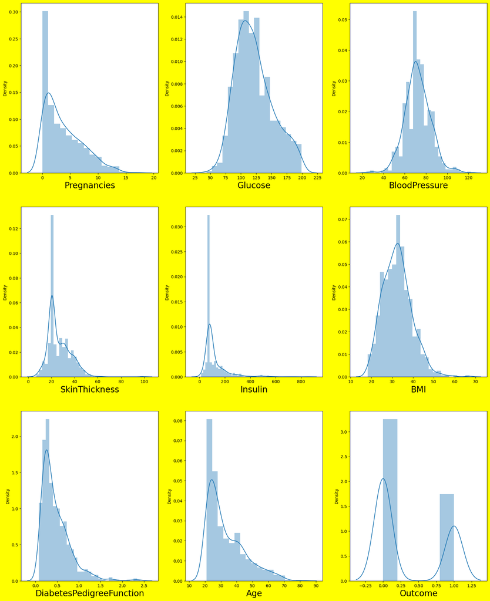

```python
# lets see how data is distributed for every columns.

plt.figure(figsize = (20,25), facecolor = 'yellow')  # figsize means lenth and width of the plot
plotnumber = 1

for column in data:
    if plotnumber<=9:                            # 9 means total columns in the data
        ax = plt.subplot(3,3,plotnumber)         # 3,3 means three rows with three columns
        sns.distplot(data[column])               # Distribution plot
        plt.xlabel(column, fontsize = 20)

    plotnumber+=1
plt.show()
```

```python
we can see there is some skewness in the data. let's deal with data.

Now we have dealt with 0 values and data looks better, But there still are outliers persent in some column.
```

```python
# separating features because outliers persent in the features not in label.
df_features = data.drop('Outcome',axis=1)
```

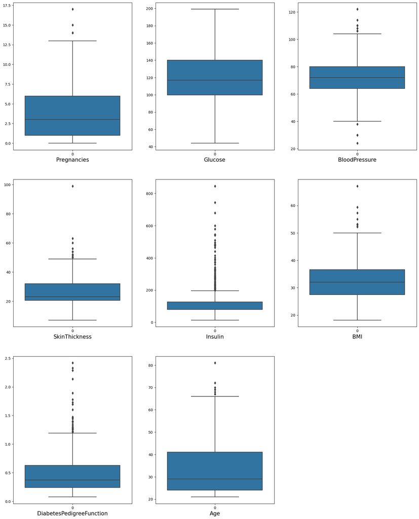

```python
# Visualising outliers using boxplot.

plt.figure(figsize = (20,25))  # figsize means lenth and width of the plot
graph = 1

for column in df_features:
    if graph<=9:
        plt.subplot(3,3,graph)
        ax = sns.boxplot(data=df_features[column])
        plt.xlabel(column, fontsize = 15)

    graph+=1
plt.show()
```

```python
data.shape
```

```
(768, 9)
```

```python
# Finf the IQR (inter quartile range) to identify outliers

# 1st quantile
q1 = data.quantile(0.25)

# 3rd quantile
q3 = data.quantile(0.75)

# IQR

iqr = q3-q1
```

```python
q1
```

```
Pregnancies                  1.000000
Glucose                     99.750000
BloodPressure               64.000000
SkinThickness               20.536458
Insulin                     79.799479
BMI                         27.500000
DiabetesPedigreeFunction     0.243750
Age                         24.000000
Outcome                      0.000000
Name: 0.25, dtype: float64
```

```python
q3
```

```
Pregnancies                   6.00000
Glucose                     140.25000
BloodPressure                80.00000
SkinThickness                32.00000
Insulin                     127.25000
BMI                          36.60000
DiabetesPedigreeFunction      0.62625
Age                          41.00000
Outcome                       1.00000
Name: 0.75, dtype: float64
```

```python
iqr
```

```
Pregnancies                  5.000000
Glucose                     40.500000
BloodPressure               16.000000
SkinThickness               11.463542
Insulin                     47.450521
BMI                          9.100000
DiabetesPedigreeFunction     0.382500
Age                         17.000000
Outcome                      1.000000
dtype: float64
```

```python
Outliers detection formula

higher side ---->>>> Q3 + (1.5*IQR)

Lower side ---->>>> Q1 - (1.5*IQR)
```

```python
# Validating one outlier    Above this value 13.5 consider as outliers
preg_high = (q3.Pregnancies + (1.5 * iqr.Pregnancies))

preg_high
```

```
13.5
```

```python
# check the indexes which have higher values
np_index = np.where(data['Pregnancies'] > preg_high)

np_index
```

```
(array([ 88, 159, 298, 455], dtype=int64),)
```

```python
# Drop the index which we found in the above cell
data = data.drop(data.index[np_index])
data.shape
```

```
(764, 9)
```

```python
# Once you drop any rows you have to reset_index otherwise will have face problems
data.reset_index()
```

|  | index | Pregnancies | Glucose | BloodPressure | SkinThickness | Insulin | BMI | DiabetesPedigreeFunction | Age | Outcome |
| --- | --- | --- | --- | --- | --- | --- | --- | --- | --- | --- |
| 0 | 0 | 6 | 148.0 | 72.0 | 35.000000 | 79.799479 | 33.6 | 0.627 | 50 | 1 |
| 1 | 1 | 1 | 85.0 | 66.0 | 29.000000 | 79.799479 | 26.6 | 0.351 | 31 | 0 |
| 2 | 2 | 8 | 183.0 | 64.0 | 20.536458 | 79.799479 | 23.3 | 0.672 | 32 | 1 |
| 3 | 3 | 1 | 89.0 | 66.0 | 23.000000 | 94.000000 | 28.1 | 0.167 | 21 | 0 |
| 4 | 4 | 0 | 137.0 | 40.0 | 35.000000 | 168.000000 | 43.1 | 2.288 | 33 | 1 |
| ... | ... | ... | ... | ... | ... | ... | ... | ... | ... | ... |
| 759 | 763 | 10 | 101.0 | 76.0 | 48.000000 | 180.000000 | 32.9 | 0.171 | 63 | 0 |
| 760 | 764 | 2 | 122.0 | 70.0 | 27.000000 | 79.799479 | 36.8 | 0.340 | 27 | 0 |
| 761 | 765 | 5 | 121.0 | 72.0 | 23.000000 | 112.000000 | 26.2 | 0.245 | 30 | 0 |
| 762 | 766 | 1 | 126.0 | 60.0 | 20.536458 | 79.799479 | 30.1 | 0.349 | 47 | 1 |
| 763 | 767 | 1 | 93.0 | 70.0 | 31.000000 | 79.799479 | 30.4 | 0.315 | 23 | 0 |

764 rows × 10 columns

```python
# same thing at once

bp_high = (q3.BloodPressure + (1.5 * iqr.BloodPressure))
print(bp_high)

index = np.where(data['BloodPressure'] > bp_high)

data = data.drop(data.index[index])
print(data.shape)

data.reset_index()
```

```
104.0
(754, 9)
```

|  | index | Pregnancies | Glucose | BloodPressure | SkinThickness | Insulin | BMI | DiabetesPedigreeFunction | Age | Outcome |
| --- | --- | --- | --- | --- | --- | --- | --- | --- | --- | --- |
| 0 | 0 | 6 | 148.0 | 72.0 | 35.000000 | 79.799479 | 33.6 | 0.627 | 50 | 1 |
| 1 | 1 | 1 | 85.0 | 66.0 | 29.000000 | 79.799479 | 26.6 | 0.351 | 31 | 0 |
| 2 | 2 | 8 | 183.0 | 64.0 | 20.536458 | 79.799479 | 23.3 | 0.672 | 32 | 1 |
| 3 | 3 | 1 | 89.0 | 66.0 | 23.000000 | 94.000000 | 28.1 | 0.167 | 21 | 0 |
| 4 | 4 | 0 | 137.0 | 40.0 | 35.000000 | 168.000000 | 43.1 | 2.288 | 33 | 1 |
| ... | ... | ... | ... | ... | ... | ... | ... | ... | ... | ... |
| 749 | 763 | 10 | 101.0 | 76.0 | 48.000000 | 180.000000 | 32.9 | 0.171 | 63 | 0 |
| 750 | 764 | 2 | 122.0 | 70.0 | 27.000000 | 79.799479 | 36.8 | 0.340 | 27 | 0 |
| 751 | 765 | 5 | 121.0 | 72.0 | 23.000000 | 112.000000 | 26.2 | 0.245 | 30 | 0 |
| 752 | 766 | 1 | 126.0 | 60.0 | 20.536458 | 79.799479 | 30.1 | 0.349 | 47 | 1 |
| 753 | 767 | 1 | 93.0 | 70.0 | 31.000000 | 79.799479 | 30.4 | 0.315 | 23 | 0 |

754 rows × 10 columns

```python
index      # these are outliers
```

```
(array([ 43,  84, 105, 175, 359, 545, 654, 658, 668, 687], dtype=int64),)
```

```python
once we delete outliers we can not plot the box plot again only once because variance will change and will keep showing outliers
if you want to check again check the distribution plot.
```

```python
st_high = (q3.SkinThickness + (1.5 * iqr.SkinThickness))
print(st_high)

index = np.where(data['SkinThickness'] > st_high)

data = data.drop(data.index[index])
print(data.shape)

data.reset_index()
```

```
49.1953125
(742, 9)
```

|  | index | Pregnancies | Glucose | BloodPressure | SkinThickness | Insulin | BMI | DiabetesPedigreeFunction | Age | Outcome |
| --- | --- | --- | --- | --- | --- | --- | --- | --- | --- | --- |
| 0 | 0 | 6 | 148.0 | 72.0 | 35.000000 | 79.799479 | 33.6 | 0.627 | 50 | 1 |
| 1 | 1 | 1 | 85.0 | 66.0 | 29.000000 | 79.799479 | 26.6 | 0.351 | 31 | 0 |
| 2 | 2 | 8 | 183.0 | 64.0 | 20.536458 | 79.799479 | 23.3 | 0.672 | 32 | 1 |
| 3 | 3 | 1 | 89.0 | 66.0 | 23.000000 | 94.000000 | 28.1 | 0.167 | 21 | 0 |
| 4 | 4 | 0 | 137.0 | 40.0 | 35.000000 | 168.000000 | 43.1 | 2.288 | 33 | 1 |
| ... | ... | ... | ... | ... | ... | ... | ... | ... | ... | ... |
| 737 | 763 | 10 | 101.0 | 76.0 | 48.000000 | 180.000000 | 32.9 | 0.171 | 63 | 0 |
| 738 | 764 | 2 | 122.0 | 70.0 | 27.000000 | 79.799479 | 36.8 | 0.340 | 27 | 0 |
| 739 | 765 | 5 | 121.0 | 72.0 | 23.000000 | 112.000000 | 26.2 | 0.245 | 30 | 0 |
| 740 | 766 | 1 | 126.0 | 60.0 | 20.536458 | 79.799479 | 30.1 | 0.349 | 47 | 1 |
| 741 | 767 | 1 | 93.0 | 70.0 | 31.000000 | 79.799479 | 30.4 | 0.315 | 23 | 0 |

742 rows × 10 columns

```python
index
```

```
(array([ 56,  84,  96, 116, 146, 205, 267, 269, 437, 523, 569, 581],
       dtype=int64),)
```

```python
insu_high = (q3.Insulin + (1.5 * iqr.Insulin))
print(insu_high)

index = np.where(data['Insulin'] > insu_high)

data = data.drop(data.index[index])
print(data.shape)

data.reset_index()
```

```
198.42578125
(657, 9)
```

|  | index | Pregnancies | Glucose | BloodPressure | SkinThickness | Insulin | BMI | DiabetesPedigreeFunction | Age | Outcome |
| --- | --- | --- | --- | --- | --- | --- | --- | --- | --- | --- |
| 0 | 0 | 6 | 148.0 | 72.0 | 35.000000 | 79.799479 | 33.6 | 0.627 | 50 | 1 |
| 1 | 1 | 1 | 85.0 | 66.0 | 29.000000 | 79.799479 | 26.6 | 0.351 | 31 | 0 |
| 2 | 2 | 8 | 183.0 | 64.0 | 20.536458 | 79.799479 | 23.3 | 0.672 | 32 | 1 |
| 3 | 3 | 1 | 89.0 | 66.0 | 23.000000 | 94.000000 | 28.1 | 0.167 | 21 | 0 |
| 4 | 4 | 0 | 137.0 | 40.0 | 35.000000 | 168.000000 | 43.1 | 2.288 | 33 | 1 |
| ... | ... | ... | ... | ... | ... | ... | ... | ... | ... | ... |
| 652 | 763 | 10 | 101.0 | 76.0 | 48.000000 | 180.000000 | 32.9 | 0.171 | 63 | 0 |
| 653 | 764 | 2 | 122.0 | 70.0 | 27.000000 | 79.799479 | 36.8 | 0.340 | 27 | 0 |
| 654 | 765 | 5 | 121.0 | 72.0 | 23.000000 | 112.000000 | 26.2 | 0.245 | 30 | 0 |
| 655 | 766 | 1 | 126.0 | 60.0 | 20.536458 | 79.799479 | 30.1 | 0.349 | 47 | 1 |
| 656 | 767 | 1 | 93.0 | 70.0 | 31.000000 | 79.799479 | 30.4 | 0.315 | 23 | 0 |

657 rows × 10 columns

```python
index
```

```
(array([  8,  13,  16,  20,  31,  39,  52,  53,  55,  71,  90, 104, 124,
        131, 136, 144, 152, 175, 184, 188, 195, 203, 208, 216, 219, 235,
        236, 242, 246, 265, 272, 273, 282, 283, 294, 305, 320, 344, 345,
        348, 354, 359, 372, 376, 379, 393, 396, 399, 408, 409, 435, 440,
        462, 467, 468, 469, 493, 501, 519, 521, 526, 527, 535, 541, 554,
        563, 572, 584, 586, 590, 623, 633, 635, 648, 654, 660, 669, 674,
        681, 684, 687, 689, 695, 722, 727], dtype=int64),)
```

```python
BMI_high = (q3.BMI + (1.5 * iqr.BMI))
print(BMI_high)

index = np.where(data['BMI'] > BMI_high)

data = data.drop(data.index[index])
print(data.shape)

data.reset_index()
```

```
50.25
(654, 9)
```

|  | index | Pregnancies | Glucose | BloodPressure | SkinThickness | Insulin | BMI | DiabetesPedigreeFunction | Age | Outcome |
| --- | --- | --- | --- | --- | --- | --- | --- | --- | --- | --- |
| 0 | 0 | 6 | 148.0 | 72.0 | 35.000000 | 79.799479 | 33.6 | 0.627 | 50 | 1 |
| 1 | 1 | 1 | 85.0 | 66.0 | 29.000000 | 79.799479 | 26.6 | 0.351 | 31 | 0 |
| 2 | 2 | 8 | 183.0 | 64.0 | 20.536458 | 79.799479 | 23.3 | 0.672 | 32 | 1 |
| 3 | 3 | 1 | 89.0 | 66.0 | 23.000000 | 94.000000 | 28.1 | 0.167 | 21 | 0 |
| 4 | 4 | 0 | 137.0 | 40.0 | 35.000000 | 168.000000 | 43.1 | 2.288 | 33 | 1 |
| ... | ... | ... | ... | ... | ... | ... | ... | ... | ... | ... |
| 649 | 763 | 10 | 101.0 | 76.0 | 48.000000 | 180.000000 | 32.9 | 0.171 | 63 | 0 |
| 650 | 764 | 2 | 122.0 | 70.0 | 27.000000 | 79.799479 | 36.8 | 0.340 | 27 | 0 |
| 651 | 765 | 5 | 121.0 | 72.0 | 23.000000 | 112.000000 | 26.2 | 0.245 | 30 | 0 |
| 652 | 766 | 1 | 126.0 | 60.0 | 20.536458 | 79.799479 | 30.1 | 0.349 | 47 | 1 |
| 653 | 767 | 1 | 93.0 | 70.0 | 31.000000 | 79.799479 | 30.4 | 0.315 | 23 | 0 |

654 rows × 10 columns

```python
index
```

```
(array([105, 164, 254], dtype=int64),)
```

```python
dpf_high = (q3.DiabetesPedigreeFunction + (1.5 * iqr.DiabetesPedigreeFunction))
print(dpf_high)

index = np.where(data['DiabetesPedigreeFunction'] > dpf_high)

data = data.drop(data.index[index])
print(data.shape)

data.reset_index()
```

```
1.2
(631, 9)
```

|  | index | Pregnancies | Glucose | BloodPressure | SkinThickness | Insulin | BMI | DiabetesPedigreeFunction | Age | Outcome |
| --- | --- | --- | --- | --- | --- | --- | --- | --- | --- | --- |
| 0 | 0 | 6 | 148.0 | 72.0 | 35.000000 | 79.799479 | 33.6 | 0.627 | 50 | 1 |
| 1 | 1 | 1 | 85.0 | 66.0 | 29.000000 | 79.799479 | 26.6 | 0.351 | 31 | 0 |
| 2 | 2 | 8 | 183.0 | 64.0 | 20.536458 | 79.799479 | 23.3 | 0.672 | 32 | 1 |
| 3 | 3 | 1 | 89.0 | 66.0 | 23.000000 | 94.000000 | 28.1 | 0.167 | 21 | 0 |
| 4 | 5 | 5 | 116.0 | 74.0 | 20.536458 | 79.799479 | 25.6 | 0.201 | 30 | 0 |
| ... | ... | ... | ... | ... | ... | ... | ... | ... | ... | ... |
| 626 | 763 | 10 | 101.0 | 76.0 | 48.000000 | 180.000000 | 32.9 | 0.171 | 63 | 0 |
| 627 | 764 | 2 | 122.0 | 70.0 | 27.000000 | 79.799479 | 36.8 | 0.340 | 27 | 0 |
| 628 | 765 | 5 | 121.0 | 72.0 | 23.000000 | 112.000000 | 26.2 | 0.245 | 30 | 0 |
| 629 | 766 | 1 | 126.0 | 60.0 | 20.536458 | 79.799479 | 30.1 | 0.349 | 47 | 1 |
| 630 | 767 | 1 | 93.0 | 70.0 | 31.000000 | 79.799479 | 30.4 | 0.315 | 23 | 0 |

631 rows × 10 columns

```python
index
```

```
(array([  4,  11,  38,  47,  83, 123, 157, 182, 204, 206, 216, 244, 256,
        276, 311, 322, 454, 502, 523, 526, 527, 560, 562], dtype=int64),)
```

```python
age_high = (q3.Age + (1.5 * iqr.Age))
print(age_high)

index = np.where(data['Age'] > age_high)

data = data.drop(data.index[index])
print(data.shape)

data.reset_index()
```

```
66.5
(622, 9)
```

|  | index | Pregnancies | Glucose | BloodPressure | SkinThickness | Insulin | BMI | DiabetesPedigreeFunction | Age | Outcome |
| --- | --- | --- | --- | --- | --- | --- | --- | --- | --- | --- |
| 0 | 0 | 6 | 148.0 | 72.0 | 35.000000 | 79.799479 | 33.6 | 0.627 | 50 | 1 |
| 1 | 1 | 1 | 85.0 | 66.0 | 29.000000 | 79.799479 | 26.6 | 0.351 | 31 | 0 |
| 2 | 2 | 8 | 183.0 | 64.0 | 20.536458 | 79.799479 | 23.3 | 0.672 | 32 | 1 |
| 3 | 3 | 1 | 89.0 | 66.0 | 23.000000 | 94.000000 | 28.1 | 0.167 | 21 | 0 |
| 4 | 5 | 5 | 116.0 | 74.0 | 20.536458 | 79.799479 | 25.6 | 0.201 | 30 | 0 |
| ... | ... | ... | ... | ... | ... | ... | ... | ... | ... | ... |
| 617 | 763 | 10 | 101.0 | 76.0 | 48.000000 | 180.000000 | 32.9 | 0.171 | 63 | 0 |
| 618 | 764 | 2 | 122.0 | 70.0 | 27.000000 | 79.799479 | 36.8 | 0.340 | 27 | 0 |
| 619 | 765 | 5 | 121.0 | 72.0 | 23.000000 | 112.000000 | 26.2 | 0.245 | 30 | 0 |
| 620 | 766 | 1 | 126.0 | 60.0 | 20.536458 | 79.799479 | 30.1 | 0.349 | 47 | 1 |
| 621 | 767 | 1 | 93.0 | 70.0 | 31.000000 | 79.799479 | 30.4 | 0.315 | 23 | 0 |

622 rows × 10 columns

```python
index
```

```
(array([ 98, 291, 366, 370, 396, 440, 543, 549, 558], dtype=int64),)
```

```python
bp_low = (q1.BloodPressure - (1.5 * iqr.BloodPressure))
print(bp_low)

index = np.where(data['BloodPressure'] < bp_low)

data = data.drop(data.index[index])
print(data.shape)

data.reset_index()
```

[output not shown]

[output not shown]

```python
index
```

```
(array([], dtype=int64),)
```

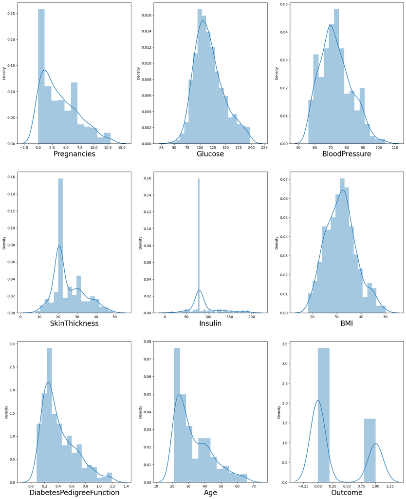

```python
plt.figure(figsize = (20,25))                    # figsize means lenth and width of the plot
plotnumber = 1

for column in data:
    if plotnumber<=9:                            # 9 means total columns in the data
        ax = plt.subplot(3,3,plotnumber)         # 3,3 means three rows with three columns
        sns.distplot(data[column])               # Distribution plot
        plt.xlabel(column, fontsize = 20)

    plotnumber+=1
plt.show()
```

```python
The data looks much better now than before. we will start our analysis with this data now as we don't want to lose
important information. if our model doesn't work with accuracy, we will comeback for more preprocessing.
```